# Data Analysis of High School Attitudinal Survey

## Visualize and interpret the model

```
The `glm()` statement creates an object which we can use to create
  the fitted probabilities
  and 95\% CIs for the population proportion at diffiner College Expectation.
The fitted probabilities and the limits are stored in columns labeled
  `fitted.values`, `fit.lower`, and `fit.upper`, respectively.
 * (1 p) Fit the `glm()` model and assess the deviance lack-of-fit test.
```

```r
# put the fitted values in the data.frame
#df.ExpectCollegeNum.gradBA.sum$fitted.values <- glm.p.a$fitted.values
#pred <- predict(glm.p.a, data.frame(ExpectCollegeNum = df.ExpectCollegeNum.gradBA.sum$ExpectCollegeNum), type = "link", se.fit = TRUE) #$
#df.ExpectCollegeNum.gradBA.sum$fitted.values <- glm.p.a$fitted.values
#pred <- predict(glm.p.a, data.frame(ExpectCollegeNum = df.ExpectCollegeNum.gradBA.sum$ExpectCollegeNum), type = "link", se.fit = TRUE) #$
df.HoursWorked.gradBA.sum$fitted.values <- glm.p.a$fitted.values
pred <- predict(glm.p.a, data.frame(HoursWorked = df.HoursWorked.gradBA.sum$HoursWorked), type = "link", se.fit = TRUE) #$

#df.ExpectCollegeNum.gradBA.sum$fit     <- pred$fit
#df.ExpectCollegeNum.gradBA.sum$se.fit  <- pred$se.fit
df.HoursWorked.gradBA.sum$fit     <- pred$fit
df.HoursWorked.gradBA.sum$se.fit  <- pred$se.fit
# CI for fitted values
#df.ExpectCollegeNum.gradBA.sum <- within(df.ExpectCollegeNum.gradBA.sum, {
#  fit.lower = exp(fit - 1.96 * se.fit) / (1 + exp(fit - 1.96 * se.fit))
#  fit.upper = exp(fit + 1.96 * se.fit) / (1 + exp(fit + 1.96 * se.fit))
#  })
df.HoursWorked.gradBA.sum <- within(df.HoursWorked.gradBA.sum, {
  fit.lower = exp(fit - 1.96 * se.fit) / (1 + exp(fit - 1.96 * se.fit))
  fit.upper = exp(fit + 1.96 * se.fit) / (1 + exp(fit + 1.96 * se.fit))
  })
```

```
* (1 p) Calculate the confidence bands around the model fit/predictions. Plot on both the logit and $\hat{p}$ scales.
    * (1 p) Interpret the sign ($+$ or $-$) of the slope parameter and test whether the slope is different from zero, $H_A: \beta_1 \ne 0$.
```

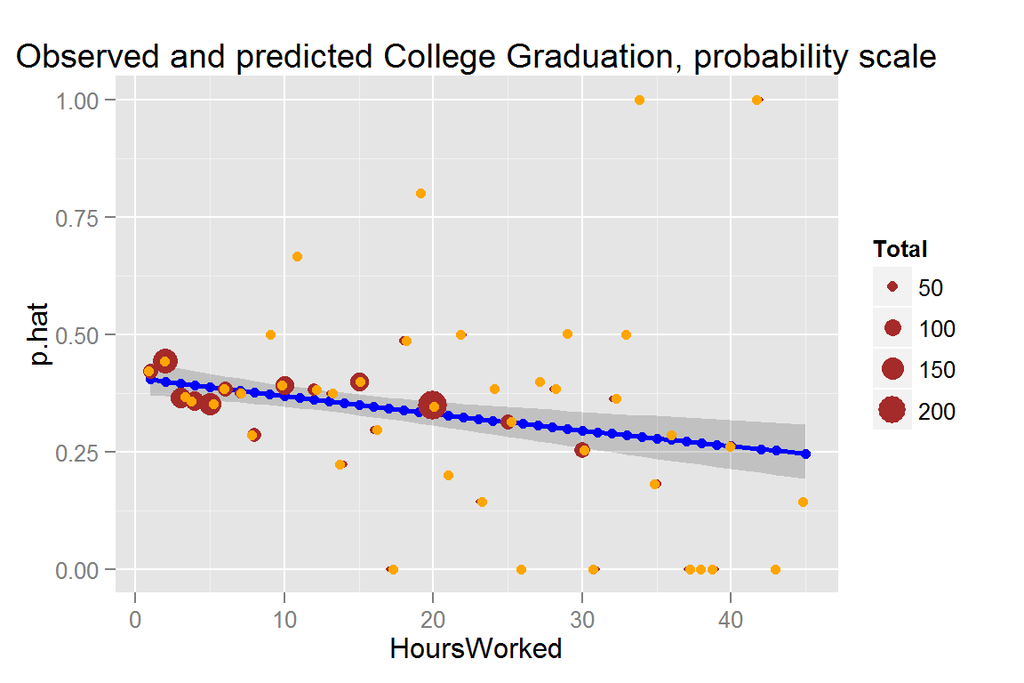

```r
# plot on probability scale
#library(ggplot2)
#p <- ggplot(df.ExpectCollegeNum.gradBA.sum, aes(x = ExpectCollegeNum, y = p.hat))
# predicted curve and point-wise 95% CI
#p <- p + geom_ribbon(aes(x = ExpectCollegeNum, ymin = fit.lower, ymax = fit.upper), colour = "blue", linetype = 0, alpha = 0.2)
#p <- p + geom_line(aes(x = ExpectCollegeNum, y = fitted.values), colour = "blue", size = 1)
# fitted values
#p <- p + geom_point(aes(y = fitted.values), colour = "blue", size=2)
# observed values
#p <- p + geom_point(aes(size = Total), color = "black")
#p <- p + expand_limits(y = 0) + expand_limits(y = 1)
#p <- p + labs(title = "Observed and predicted College Graduation, probability scale")
#print(p)
#
p <- ggplot(df.HoursWorked.gradBA.sum, aes(x = HoursWorked, y = p.hat))
# predicted curve and point-wise 95% CI
p <- p + geom_ribbon(aes(x = HoursWorked, ymin = fit.lower, ymax = fit.upper), colour = "blue", linetype = 0, alpha = 0.2)
p <- p + geom_line(aes(x = HoursWorked, y = fitted.values), colour = "blue", size = 1)
# fitted values
p <- p + geom_point(aes(y = fitted.values), colour = "blue", size=2)
# observed values
p <- p + geom_point(aes(size = Total), color = "brown")
p <- p + geom_point(position = position_jitter(width=0.3), colour = "orange")
p <- p + expand_limits(y = 0) + expand_limits(y = 1)
p <- p + labs(title = "Observed and predicted College Graduation, probability scale")
print(p)
```

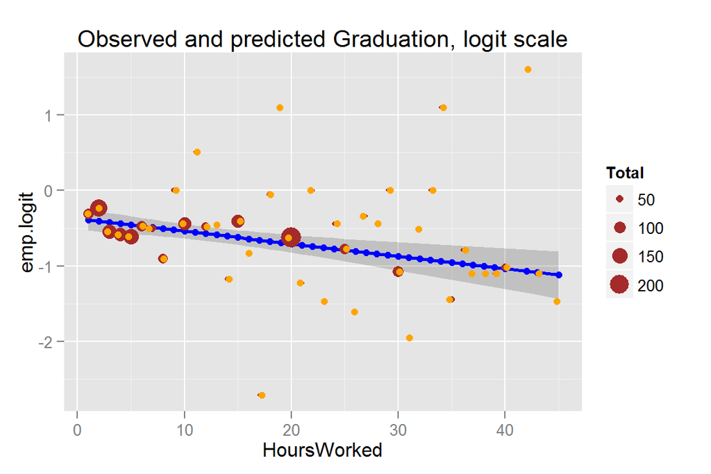

```r
# plot on logit scale
#library(ggplot2)
#p <- ggplot(df.ExpectCollegeNum.gradBA.sum, aes(x = ExpectCollegeNum, y = emp.logit))
# predicted curve and point-wise 95% CI
#p <- p + geom_ribbon(aes(x = ExpectCollegeNum, ymin = fit - 1.96 * se.fit, ymax = fit + 1.96 * se.fit), linetype = 0, alpha = 0.2)
#p <- p + geom_line(aes(x = ExpectCollegeNum, y = fit), colour = "blue", size = 1)
# fitted values
#p <- p + geom_point(aes(y = fit), colour = "blue", size=2)
# observed values
#p <- p + geom_point(aes(size = Total), color = "black")
#p <- p + labs(title = "Observed and predicted Graduation, logit scale")
#print(p)
#
p <- ggplot(df.HoursWorked.gradBA.sum, aes(x = HoursWorked, y = emp.logit))
# predicted curve and point-wise 95% CI
p <- p + geom_ribbon(aes(x = HoursWorked, ymin = fit - 1.96 * se.fit, ymax = fit + 1.96 * se.fit), linetype = 0, alpha = 0.2)
p <- p + geom_line(aes(x = HoursWorked, y = fit), colour = "blue", size = 1)
# fitted values
p <- p + geom_point(aes(y = fit), colour = "blue", size=2)
# observed values
p <- p + geom_point(aes(size = Total), color = "brown")
p <- p + geom_point(position = position_jitter(width=0.3), colour = "orange")
p <- p + labs(title = "Observed and predicted Graduation, logit scale")
print(p)
```

**model fit** I feel comfortable about the model fit. The logit scale reveals that data can be fit onto a straight line (within a logarithmic view). Let’s consider those people who work 30 or more hours.

```r
#subset(df.ExpectCollegeNum.gradBA.sum, ExpectCollegeNum == 2)
subset(df.HoursWorked.gradBA.sum, HoursWorked == 30)
```

```
   HoursWorked Total Success     p.hat emp.logit fitted.values        fit
30          30    99      25 0.2525253 -1.072121     0.2952157 -0.8701857
       se.fit fit.upper fit.lower
30 0.09501287 0.3353779 0.2579959
```

The summary table gives MLEs and standard errors for the regression parameters. The z-value column is the parameter estimate divided by its standard error. The p-values are used to test whether the corresponding parameters of the logistic model are zero.

```r
#summary(glm.p.a)
summary(glm.p.a)
```

```
Call:
glm(formula = cbind(Success, Total - Success) ~ HoursWorked,
    family = binomial, data = df.HoursWorked.gradBA.sum)

Deviance Residuals:
     Min        1Q    Median        3Q       Max
-2.42031  -0.81126   0.03793   0.61403   2.33597

Coefficients:
             Estimate Std. Error z value Pr(>|z|)
(Intercept) -0.373064   0.075416  -4.947 7.55e-07 ***
HoursWorked -0.016571   0.004668  -3.550 0.000385 ***
---
Signif. codes:  0 '***' 0.001 '**' 0.01 '*' 0.05 '.' 0.1 ' ' 1

(Dispersion parameter for binomial family taken to be 1)

    Null deviance: 60.635  on 42  degrees of freedom
Residual deviance: 47.717  on 41  degrees of freedom
AIC: 174.19

Number of Fisher Scoring iterations: 3
```

```r
  # see names(summary(glm.p.a)) to find the object that has the coefficients.
  # can also use coef(glm.p.a)
```

# 13 Conclusion

1. **(1 p)** Introduction
- I would like to know if working hours (categorical explanatory) during high school is associated with college expectations (categorical response). And, does parental college concern moderate this hypothesized association?
- Secondly, I’m interested to see if levels of parental college support/concern (categorical explanatory) during high school is associated with college expectations (categorical response).
- A specific example I’m testing involves whether it is true that very traditional Latino parents, if low-income bracket, encourage sons to help the family by working a couple years after graduating high school. In contrast, daughters are discouraged from being a “breadwinner.” Rather, daughters are encouraged to go directly to college. Therefore, I hypothesize that working hours during adolescence is negatively associated with level of college expectation, yet this relation is conditioned by parental college concern.
- Based on the literature, I situate the parental association with students’ college expectations within the psychology, education, and sociology peer-reviewed articles around ‘family influence’. More specifically, the publications that frame parental influence in theoretical terms of “Social Control via Family Bonding”, i.e., Family Attachment. My research looks at the “dark side” of parental influence rather than the usual “protective factors.” I did not find any articles so far on Latino parental conditioning of the working and college expectation relationship. ``` The Relationships at Play

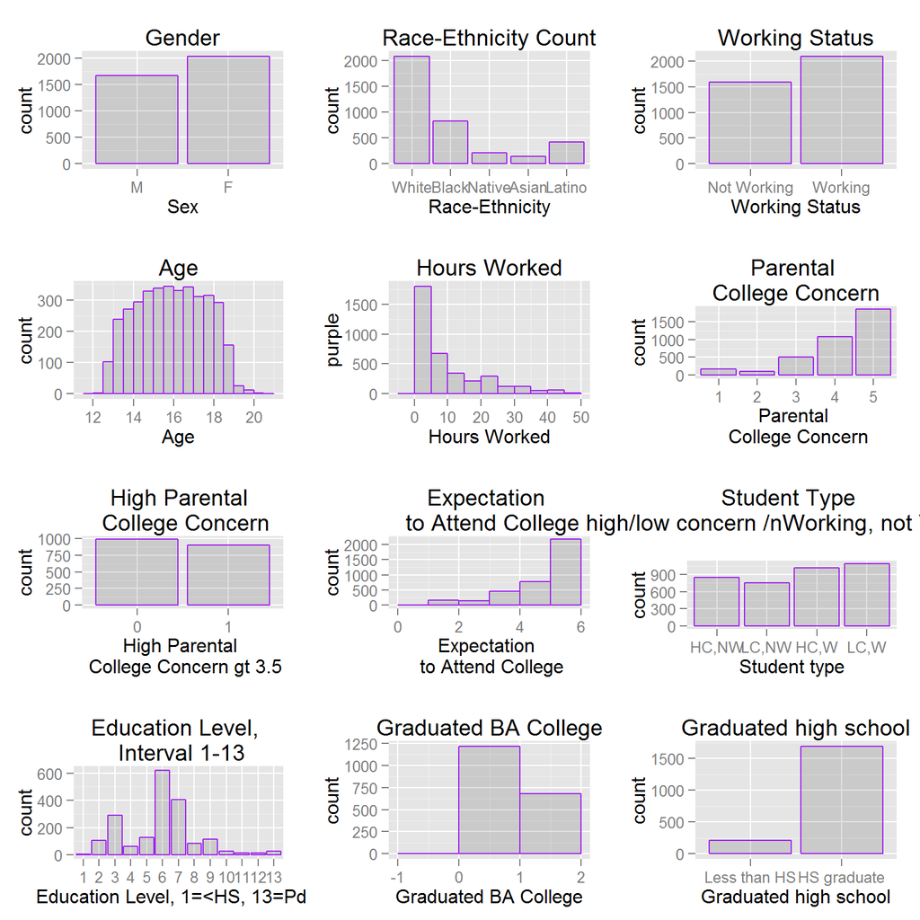

```r
library(ggplot2)
a <- ggplot(data = addhealth.sub, aes(x = Sex))
a <- a + geom_bar(binwidth = 1, alpha = .15, color = "purple")
a <- a + labs(title = "Gender", x = "Sex")

b <- ggplot(data = addhealth.sub, aes(x = RaceEth))
b <- b + geom_bar(binwidth = 1, alpha = .15, color = "purple")
b <- b + labs(title = "Race-Ethnicity Count", x = "Race-Ethnicity")

c <- ggplot(data = addhealth.sub, aes(x = Working))
c <- c + geom_bar(binwidth = 1, alpha = .15, color = "purple")
c <- c + labs(title = "Working Status", x = "Working Status")

d <- ggplot(data = addhealth.sub, aes(x = Age))
d <- d + geom_bar(binwidth = .5, alpha = .15, color = "purple")
d <- d + labs(title = "Age", x = "Age")

e <- ggplot(data = addhealth.sub, aes(x = HoursWorkedCat))
e <- e + geom_bar(binwidth = 5, alpha = .15, color = "purple")
e <- e + labs(title = "Hours Worked", x = "Hours Worked", y = "purple")

f <- ggplot(data = addhealth.sub, aes(x = ParenConcernMean))
f <- f + geom_bar(binwidth = 1, alpha = .15, color = "purple")
f <- f + labs(title = "Parental \nCollege Concern", x = "Parental \n College Concern", y = "count")

g <- ggplot(data = addhealth.sub.f, aes(x = HighParenCollConcern))
g <- g + geom_bar(binwidth = 1, alpha = .15, color = "purple")
g <- g + labs(title = "High Parental \n College Concern", x = "High Parental \n College Concern gt 3.5", y = "count")

h <- ggplot(data = addhealth.sub, aes(x = ExpectCollegeNum))
h <- h + geom_bar(binwidth = 1, alpha = .15, color = "purple")
h <- h + labs(title = "Expectation \n to Attend College", x = "Expectation \n to Attend College", y = "count")

i <- ggplot(data = addhealth.sub, aes(x = Studen))
i <- i + geom_bar(binwidth = 1, alpha = .15, color = "purple")
i <- i + labs(title = "Student Type \n high/low concern /nWorking, not Working
              ", x = "Student type", y = "count")

j <- ggplot(data = addhealth.sub.f, aes(x = education))
j <- j + geom_bar(binwidth = 1, alpha = .15, color = "purple")
j <- j + labs(title = "Education Level, \n Interval 1-13", x = "Education Level, 1=<HS, 13=PdD", y = "count")

k <- ggplot(data = addhealth.sub.f, aes(x = gradBA))
k <- k + geom_bar(binwidth = 1, alpha = .15, color = "purple")
k <- k + labs(title = "Graduated BA College", x = "Graduated BA College", y = "count")

l <- ggplot(data = addhealth.sub.f, aes(x = gradHS))
l <- l + geom_bar(binwidth = 1, alpha = .15, color = "purple")
l <- l + labs(title = "Graduated high school", x = "Graduated high school", y = "count")
library(gridExtra)
grid.arrange(a, b, c, d, e, f, g, h, i, j, k, l, nrow=4)
```

2. **(1 p)** Research Questions

**MAIN RESEARCH QUESTION**: Does Parental College Concern moderate (i.e. strength or direction of association) the negative assocation between working hours and college expectation among high school students? And 20 years later?

**RQ1**: What is the relationship between respondent working hours VS respondent expectation to go to college?

**RQ2**: Does low parental concern accentuate the hypothesized association between adolescent-working hours vs college expectation?

**RQ3**: What is the longitudinal outcome, i.e., later Wave 4 college graduation?

*Research Question I. **H1**: I hypothesize that the Wave 4 college graduation outcome variable (probability of success) is negatively associated with working hours in high school.

- Research Question II **H2**: Parenting college concern moderates the working-in-high-school and expectation-to-go-to-college relationship.

**H2alt**: There is no interaction effect between Parenting college concern and working-in-high-school in the association with expectation-to-go-to-college.  
Especially when conditioned by the intersection of Latino race and Male gender.

- Research Question III **H3**: H1 and H2 have statistically significant longitudinal associations. Especially when conditioned by the intersection of Latino race and Male gender.

3. **(1 p)** Methods
   - (Various) Statistical methods used to answer the research questions.
   - Using Codebook of AddHealth Wave1 literature review via Mendeley, Extensive use of AddHealthW1_CodeBook.pdf
   - Wave I-VarName Variable description Data type (Continuous, Discrete, Nominal, Ordinal) Frequency ItemValue Description AID (Wave 1) UNIQUE ID NUMBER WITH NO ALPHABETICS Nominal Unique Identification number BIO_SEX GENDER MALE 2 = female 1 = male 6 = NA Nominal H1EE2 EXPECTATION TO GO TO COLLEGE ExpectCollege: 1-5; 6=refused, 8=don’t know, 9=NotApplic Discrete 1-5. 1= low; 5=high H1EE3 WHETHER WORKED IN PAST FOUR WEEKS Working: 0=no, 1=yes, 6=refused, 8=don’t know H1EE4 HOURS WORKED OUTSIDE HOME IN TYPICAL NON-SUMMER WEEK H1WP11 STUDENT-PERCEIVED MOTHER PARENTAL CONCERN ABOUT COLLEGE Interval ParentConcernM: 1-5;  
     6=refused, 7=noDad 8=don’t know, 9=NotApplic 1-5. 1 = low concern; 5=high concern H1WP16 STUDENT-PERCEIVED FATHER PARENTAL CONCERN ABOUT COLLEGE Interval ParentConcernF: 1-5;  
     6=refused, 7=noDad 8=don’t know, 9=NotApplic 1-5. 1 = low concern; 5=high concern H4ED1 (gradHS) What is your high school graduation status? 1=Finished high school with diploma 2=Earned a high school equivalency degree (GED) 3=Earned a Certificate of attendance or a certificate of completion 4=Did not receive hs diploma, GED or other certificate 6=Refused 8=don’t know
   - Wave IV-VarName H$ED2 (gradBA) What is the highest level of education that you have acheived to date? 1=8th grade or less 2=Some high school 3=high school graduate 4=Some vocationalized training (after high school) 5=Completed vocationalized training (after high school)  
     6 =Some College 7=Completed a Bachelor’s 8=Some Graduate School 9=Completed a master’s degree 10=Some graduate training beyond a master’s degree 11=Completed a doctoral degree 12=Medical degree 13=Medical degree Constructed variables AGE (Age)
- AGE: age = (mdy(imonth,iday,1995)-mdy(h1gi1m,15,(h1gi1y+1900)))/365.25 Continuous
- gradBA >= 7
- education
- gradHS Graduate HS = 1==1; Non Graduate HS = 0 == vs. 0;
- (Various) Statistical methods used to answer the research questions. ```
4. **(1 p)** Discussion:
- The results support the initial hypotheses in which I expected work hours (especially if conditioned by low parental concern) to be negativately associated with work. This finding was however contradicted by the findings for Latino Males, that behaved the opposite as others. Latino males and females, though lower parental college concern, increased in college expectations with more hours worked.